# Resilienz der Zukunft

Wenn Technik entscheidet, Systeme lernen und Verantwortung diffus wird · Termin 10

Prof. Dr. Dirk Loomans

Hochschule Mainz · dirk.loomans@hs-mainz.de

## Resilienz der Zukunft

**Quanten, Autonomie und Verantwortung unter Unsicherheit**

- Resilienz endet nicht bei Technik.
- Zukünftige Systeme verändern Zeit, Kontrolle und Verantwortung.
- Diese Sitzung blickt bewusst über heutige Annahmen hinaus.

## Rückblick: Unser Resilienzverständnis bisher

- Resilienz ≠ Vermeidung von Störungen
- Resilienz = Reagieren · Wiederherstellen · Anpassen
- Zusammenspiel aus
  - Technik (Architekturen, Backups, DR)
  - Organisation (Rollen, Prozesse, Kommunikation)
  - Mensch (Entscheidung, Verantwortung, Lernen)

## Die implizite Annahme

**Der Mensch ist die letzte Entscheidungsinstanz.**

- Entscheidungen sind erklärbar.
- Verantwortung ist zuordenbar.
- Kontrolle ist zumindest theoretisch möglich.

## Bruchlinie: Was sich gerade verändert

- Kryptografie kann rückwirkend brechen.
- Systeme entscheiden schneller als Menschen.
- Entscheidungen werden ausgelagert – an Modelle, Plattformen, Algorithmen.
- Verantwortung verteilt sich über Lieferketten.

## Struktur der Sitzung

1. Quantencomputing – wenn Vertrauen rückwirkend bricht
2. Autonome Systeme – wenn Systeme selbst reagieren
3. Gesellschaft & Ethik – wenn niemand allein verantwortlich ist
4. Zusammenführung – was bedeutet das für Cyber-Resilienz?

## Übergang: Resilienz & Zeit

- Resilienz misst sich über Zeit.
- Annahme bisher: Die Vergangenheit bleibt stabil; Entscheidungen wirken nur nach vorn.
- **Neue Frage: Was, wenn die Vergangenheit unsicher wird?**

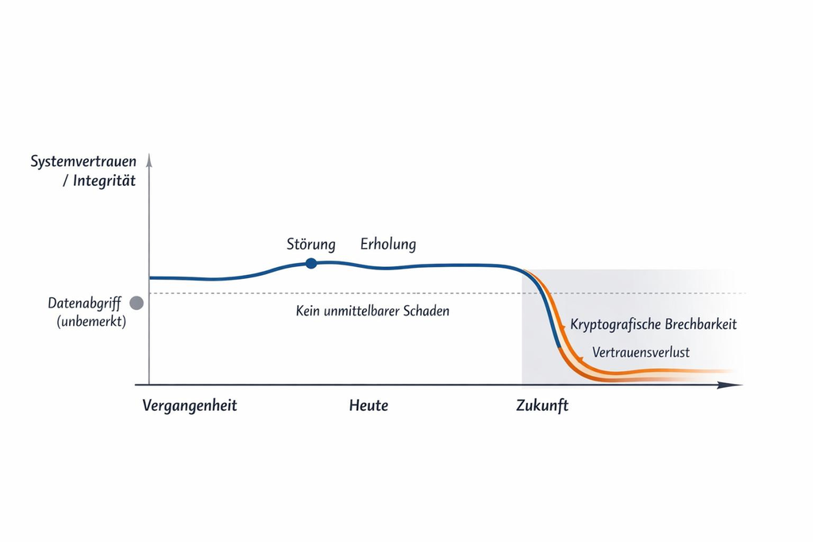

## Einstieg Quantencomputing

- Quantencomputer sind keine schnelleren PCs.
- Sie bedrohen gezielt asymmetrische Kryptografie (RSA, ECC), digitale Signaturen und langfristige Vertraulichkeit.
- Angriffsszenario: **„Harvest now, decrypt later“**

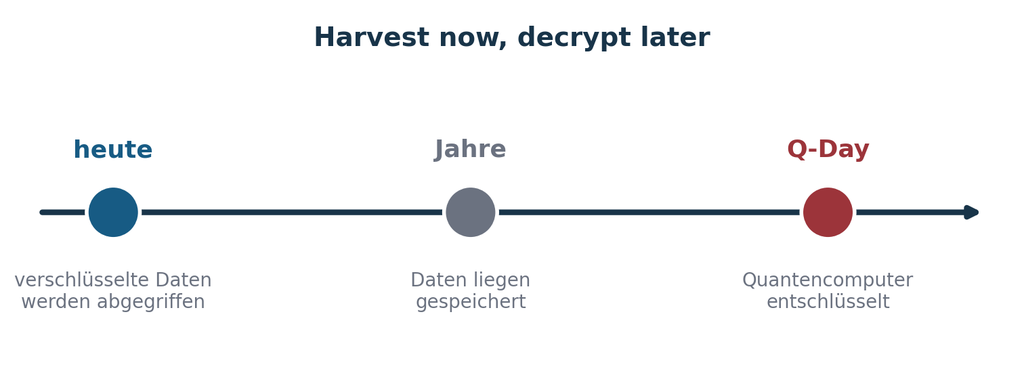

## Quantencomputing als Resilienzproblem

**Kein Security-, sondern ein Resilienzthema**

- Schaden entsteht zeitverzögert.
- Betroffen: Archive, Backups, Identitäten, Vertrauensketten.
- Klassische Prävention greift zu kurz.
- Vertrauensverlust lässt sich nicht durch Wiederanlauf reparieren.

## Crypto Agility als Resilienzfähigkeit

**Anpassungsfähigkeit statt Algorithmus-Fetisch**

- Kryptografie ist kein statischer Zustand.
- Resiliente Systeme können Algorithmen austauschen, Schlüssel erneuern, Vertrauensketten migrieren.
- Ziel: Schaden begrenzen, nicht Unverwundbarkeit.

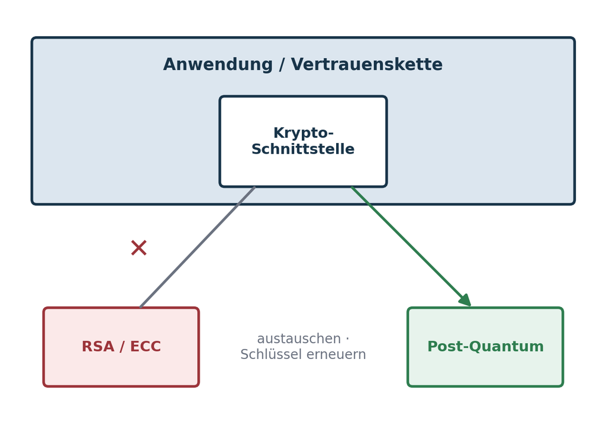

## Grenzen technischer Resilienz (Quanten)

- Langzeitarchive können nicht „einfach neu signiert“ werden.
- Vertrauensbeziehungen wirken organisationsübergreifend.
- Migration erzeugt neue Risiken: Inkompatibilität, Betriebsunterbrechungen, Fehlkonfiguration.

## Zwischenfazit Quantencomputing

- Resilienz betrifft Vergangenheit, Gegenwart und Zukunft.
- Vertrauen wird zeitabhängig.
- Zentrale Fähigkeit: vorausschauende Anpassung.

„Resilienz bedeutet künftig, mit unsicherer Vergangenheit zu leben.“

## Übergang: Von Zeit zu Entscheidung

- Bisher: Mensch entscheidet, System führt aus.
- Neu: Systeme reagieren selbstständig.
- Resilienz wird schneller – aber weniger transparent.

## Was sind autonome Systeme?

- Selbstüberwachende Systeme
- Automatisierte Incident Response
- Self-healing Infrastructure
- KI-gestützte Entscheidungen ohne menschliche Freigabe

## Das Resilienz-Paradoxon autonomer Systeme

**Autonome Systeme erhöhen**

- Reaktionsgeschwindigkeit
- Skalierbarkeit
- Konsistenz

**Gleichzeitig sinken**

- Transparenz
- Nachvollziehbarkeit
- menschliche Kontrolle

**Autonomie erhöht operative Resilienz … und senkt epistemische Resilienz.**

## Geschwindigkeit vs. Kontrolle

- Menschliche Entscheidungen: langsam, reflektiert
- Autonome Entscheidungen: schnell, aber kontextarm
- In Krisen: Geschwindigkeit rettet Systeme – Fehlentscheidungen skalieren sofort.

Wann ist menschliches Zögern Teil der Resilienz?

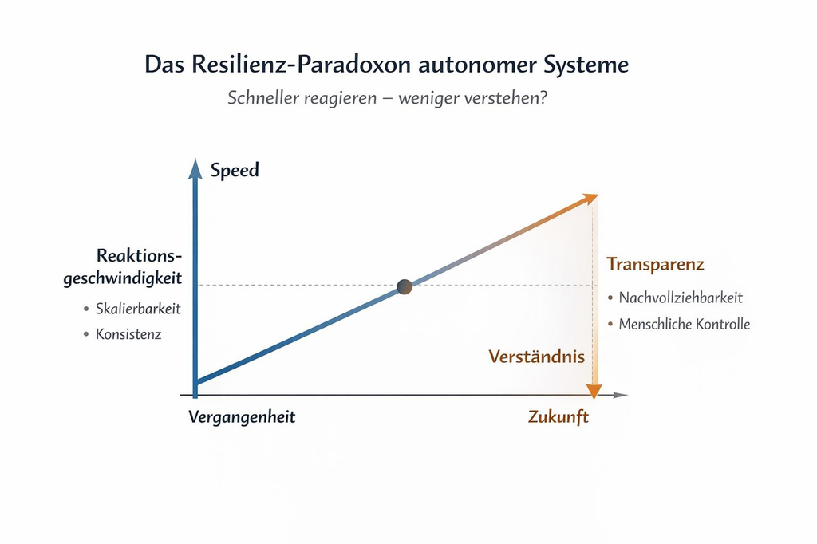

## Lernen als Risiko

- ML-Systeme passen ihr Verhalten an – auf Basis von Trainingsdaten, Feedback, impliziten Zielen.
- Risiken: Overfitting auf Krisen, falsche Korrelationen, unerwünschte Optimierung.

## Adaptivität ≠ Kontrollverlust

**Autonomie braucht Leitplanken**

- Klare Grenzen für autonome Entscheidungen
- Menschliche Eingriffspunkte („Human Override“)
- Transparenz & Logging
- Vorab definierte „No-Go“-Zonen

## Verantwortung im autonomen Betrieb

**Wer trägt Verantwortung, wenn niemand entscheidet?**

- Entscheidung ≠ Verantwortung
- Verantwortung verteilt sich über Entwickler, Betreiber, Management und Anbieter.
- Klassische Rollenkonzepte geraten an Grenzen.

## Zwischenfazit Autonome Systeme

- Mehr Geschwindigkeit ≠ bessere Resilienz.
- Transparenz wird zum kritischen Gut.
- Resilienz braucht Technik, Governance und Ethik.

„Ein System, das sich selbst heilt, muss sich auch selbst erklären können.“

## Resilienz ist kein rein technisches Ziel

- Resiliente Systeme entscheiden über Versorgung, Teilhabe und Sicherheit.
- Technische Entscheidungen haben soziale Effekte.
- Resilienz ist immer normativ (wertbehaftet).

## Wer profitiert von Resilienz?

**Große Organisationen**

- mehr Redundanz
- mehr Ressourcen

**Kleine Akteure**

- höhere Abhängigkeiten
- geringere Ausweichmöglichkeiten

Resilienz kann Ungleichheit verstärken.

## Automatisierte Entscheidungen & Legitimität

- Autonome Systeme priorisieren Services, Nutzer, Regionen.
- Kriterien sind oft technisch sinnvoll, aber gesellschaftlich intransparent.
- Problem: fehlende Legitimation.

## Verantwortung ohne Verantwortliche

**Das Verantwortungsdiffusions-Problem**

- Cloud · KI-Modelle · Lieferketten · Open Source
- → Verantwortung verteilt sich.
- → Haftung, Erklärung, Kontrolle werden unscharf.

## Ethik als Resilienz-Leitplanke

**Ethik ist keine Bremse, sondern Orientierung.**

- Was darf ein System? Was soll es nicht?
- Besonders relevant bei autonomen Entscheidungen, Ressourcenknappheit und Krisenpriorisierung.

## Resilienz vs. Freiheit

- Mehr Resilienz bedeutet oft mehr Überwachung, mehr Kontrolle, weniger Autonomie für Individuen.
- Zielkonflikt: Schutz vs. Freiheit – technisch nicht auflösbar.

## Zwischenfazit Gesellschaft & Ethik

- Technisch robuste Systeme können sozial scheitern.
- Akzeptanz entsteht durch Transparenz, Fairness, Verantwortlichkeit.
- Resilienz ohne Legitimität ist instabil.

„Ein resilientes System, dem niemand vertraut, ist nicht resilient.“

## Resilienz der Zukunft: alles zusammen gedacht

- Quantencomputing verändert Zeit & Vertrauen.
- Autonome Systeme verändern Entscheidung & Kontrolle.
- Gesellschaft & Ethik verändern Legitimität & Akzeptanz.
- Resilienz entsteht im Spannungsfeld aller drei.

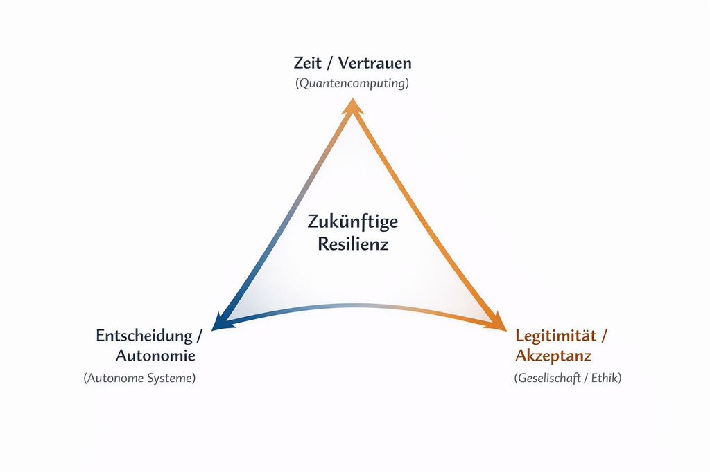

## Neue Resilienzfragen

- Wie viel Autonomie verträgt ein System?
- Wo muss der Mensch zwingend entscheiden?
- Wie erklären wir maschinelle Entscheidungen?
- Wie lange muss Vertrauen halten?
- Wer trägt Verantwortung im Grenzfall?

## Neue Resilienzfähigkeiten

- Crypto Agility (nicht nur Post-Quantum)
- Governance für Autonomie
- Erklärbarkeit & Transparenz
- Ethische Leitplanken
- Gesellschaftliche Einbettung

## Resilienz als Führungsaufgabe

- Entscheidungen sind strategisch.
- Auswirkungen sind gesellschaftlich.
- Verantwortung liegt bei Führung & Governance.
- **IT liefert Fähigkeiten – nicht Werte.**

## Übung: Resilienz im Jahr 2035

Europaweites Versorgungsunternehmen: autonome IT/OT-Steuerung, KI-gestützte Incident Response, teilweise Post-Quantum-Kryptografie.

**Montagmorgen:** Unstimmigkeiten in historischen Signaturen eines Archivs · auffällige Reaktionen autonomer Schutzsysteme · regionale Diensteinschränkungen zur „Stabilisierung“ – ein Angriff ist nicht eindeutig nachweisbar.

Rollen: A Technik/Security · B Management · C Staat/Aufsicht · D Gesellschaft/Kunden · E Ethik/Recht

Aufgaben: Resilienzverständnis · kritische Entscheidung der nächsten 30 Minuten · Grenzen der Autonomie · Verantwortung & Kommunikation. Es geht um Begründbarkeit, nicht um Konsens.

## Abschlussstatement

Die größte Herausforderung zukünftiger Resilienz ist nicht Technik –

**sondern Verantwortung unter Unsicherheit.**

„Resilienz ist keine Eigenschaft von Systemen. Sie ist eine Fähigkeit von Menschen, Organisationen und Gesellschaften.“

## Material

Kapitel zum Termin · Glossar · Quellen